# 手を動かしながら学ぶモダンなデータ操作とtidyなデータ（2016年版）

Shinya Uryu

2015年12月1日

**R Advent Calender 2015の第一目です。**

今日はタイトルの通り、**`{dplyr}`**と**`{tidyr}`**パッケージを使ったデータの整形と集計処理について、実際のデータを交えながら紹介したいと思います（タイトルは流行りの本から撮ってきました。オマージュです）。

**`{dplyr}`**と**`{tidyr}`**パッケージ、関数の使い方を紹介した記事はあっても、実際のデータを扱った記事を検索しても、日本語の記事がほとんど見つからなかったので、tidyなデータ形式について普及させるために記事を書こうというところです。

一応、自分が集められたtidyデータについての記事へのリンクを貼っておきます。

- [R dplyr, tidyr でのグルーピング/集約/変換処理まとめ - StatsFragments](http://sinhrks.hatenablog.com/entry/2014/10/13/003717)
- [メモ：dplyr::mutate()の中でstr_split()したいと思ったとき、使うのはtidyr::separate()だ - Technically, technophobic.](http://notchained.hatenablog.com/entry/2015/06/29/233237)

ちょっと前に海外の方がtidyデータについての記事を書かれていましたので、こちらも参考になります。

- [Cleaning and visualizing genomic data: a case study in tidy analysis – Variance Explained](http://varianceexplained.org/r/tidy-genomics/)

## tidyデータとは

Rだけに限った話ではありませんが、データ解析のために用いられる時間の大半は、手持ちのデータを解析処理を行う関数やツールが扱えるようにするためのデータの整形作業です。いわゆる前処理と呼ばれるこの作業は、データ解析の最初の段階としての作業であり、のちの解析にも大きな影響を及ぼす重要な過程と成っています。

Hadleyの提唱するtidyデータはデータを規則正しい形に整形することで、データの操作、解析、可視化を柔軟に扱えるようにすることを目指しています。 より詳しい内容について知りたい方はHadleyの[論文](http://vita.had.co.nz/papers/tidy-data.html)を読んでください。

tidyデータの要点は次のようになります。

- 一つの変数に対して一つの列が与えられるべし（同一の変数を複数の列にまたがせない）
- それぞれの観測値は一つの行に収めるべし（同一の個体に対して複数の行を与えない）
- 観測データの集合は表形式で表現することができる

### {tidyr}パッケージ

R界の「神」こと[Hadley Wickham](https://github.com/hadley)が中心になって開発されるRパッケージに**`{tidyr}`**というものがあります。これはRでのデータ処理に優れた**`{reshape2}`**をベースにしており、かつ上記のtidyデータの概念を反映しており、手持ちのデータをtidy形式に（柔軟な操作ができるように）する関数や、その他、データの処理のための関数を備えています。

主要な関数

- `gather()`
- `spread()`
- `separate()`

補助的な関数

- `extract_numeric()`
- `unite()`

## 扱うデータについて: モニタリングサイト1000

せっかくなので公開されているデータを使用します。

環境省が行っている業務の一つに「[モニタリングサイト1000](http://www.biodic.go.jp/moni1000/moni1000/)（通称: モニセン）」というものがあります。これはさまざまな生態系を対象として日本全国各地にモニタリングサイトを設置し、長期的な観測によりその変化や構造について明らかにしようという壮大なプロジェクトです。みなさんどこかで耳にしたことがあるのではないでしょうか。

このモニセン業務では、収集されたデータを公開しており、利用用途などのアンケートに答えることでそのデータをダウンロードできます。

今回は「モニタリングサイト1000森林・草原調査」で行われている調査の１つのである毎木調査（特定の面積内に生育する樹木を対象としたサイズの調査）から、北海道の「雨竜」プロットのデータを例にしてtidyデータの説明を行いたいと思います。

名前がいいですよね。親しみを感じます。行ってみたいプロットの一つです。

このデータでは、2005年から2012年の８年間分の毎木のデータが収められています。また、幹の状態を記録するためのメモが追加されています。

## データの読み込みからtidy形式への変形

今回利用するRパッケージを読み込みます。

```r
library(ggplot2)
library(readxl)
library(broom)
library(tidyr)
library(dplyr)
quartzFonts(YuGo = quartzFont(rep("YuGo-Medium", 4)))
theme_set(theme_classic(base_size = 12, base_family = "YuGo"))
```

```r
df_uryu <- read_excel(path = "UR-BC1-TreeGbh-2005-2012-ver1.xls",
                    sheet  = 1,
                    skip   = 86)
```

```r
names(df_uryu)
```

```
##  [1] "mesh_xcord"          "mesh_ycord"          "tag_no"
##  [4] "indv_no"             "stem_xcord"          "stem_ycord"
##  [7] "spc_japan"           "gbh05"               "gbh06"
## [10] "gbh07"               "gbh08"               "gbh09"
## [13] "gbh10"               "gbh11"               "gbh12"
## [16] "note05"              "note06"              "note07"
## [19] "note08"              "note09"              "note10"
## [22] "note11"              "note12"              "s_date05"
## [25] "s_date06"            "s_date07"            "s_date08"
## [28] "s_date09"            "s_date10"            "s_date11"
## [31] "s_date12"            "stem_id"             "indv_id"
## [34] "stem_xcord_original" "stem_ycord_original" "tag_no05"
## [37] "indv_no05"           "tag_no09"            "indv_no09"
```

読み込んだデータの変数名を確認しました。ちょっと多いので、分析に利用しない列をデータから除いてデータをちょっと軽くします。変数の選択には`dplyr::select()`が便利です。正規表現や条件分岐を利用して列の選択ができます。この時に使用できるオプションについては@hoxo_m さんの以下の記事が詳しいので参考にしてください。

http://qiita.com/hoxo_m/items/f2f1793c6f086d381340

```r
df_uryu %<>% dplyr::select(-ends_with("cord"), -contains("s_date"),
                           -starts_with("stem_"), -starts_with("indv_no"),
                           -tag_no05, -tag_no09)
```

変数が多い（19列）ので`glimpse()`を使って横方向にすべての変数のデータのいくつかを表示します。

```r
glimpse(df_uryu)
```

```
## Observations: 849
## Variables: 19
## $ tag_no    (dbl) 1, 2, 3, 4, 5, 6, 7, 8, 9, 10, 11, 12, 13, 14, 15, 1...
## $ spc_japan (chr) "ナナカマド", "トドマツ", "トドマツ", "シナノキ", "イタヤカエデ", "ナナカマド", ...
## $ gbh05     (dbl) 17.0, 161.9, 105.0, 28.6, 89.7, 23.2, 84.9, 223.7, 1...
## $ gbh06     (dbl) 17.5, 163.2, 109.3, 30.3, 90.7, 24.5, 84.9, 224.2, 1...
## $ gbh07     (dbl) 18.4, 163.8, 109.3, 31.8, 93.1, 25.5, 85.0, 224.8, 2...
## $ gbh08     (dbl) 19.2, 165.2, 114.3, 33.3, 92.9, 25.7, 85.1, 224.8, 2...
## $ gbh09     (dbl) 20.2, 165.2, 114.3, 35.4, 95.9, 27.5, 85.1, 224.8, 2...
## $ gbh10     (chr) "21.000000", "165.200000", "117.000000", "37.000000"...
## $ gbh11     (dbl) 22.0, 165.4, 117.3, 39.0, 96.2, 29.0, NA, 224.9, 200...
## $ gbh12     (chr) "22.000000", "167.400000", "121.500000", "40.000000"...
## $ note05    (dbl) NA, NA, NA, NA, NA, NA, NA, NA, NA, NA, NA, NA, NA, ...
## $ note06    (dbl) NA, NA, NA, NA, NA, NA, NA, NA, NA, NA, NA, NA, NA, ...
## $ note07    (dbl) NA, NA, NA, NA, NA, NA, NA, NA, NA, NA, NA, NA, NA, ...
## $ note08    (dbl) NA, NA, NA, NA, NA, NA, NA, NA, NA, NA, NA, NA, NA, ...
## $ note09    (dbl) NA, NA, NA, NA, NA, NA, NA, NA, NA, NA, NA, NA, NA, ...
## $ note10    (chr) NA, NA, NA, NA, NA, NA, "枯死", NA, NA, NA, NA, NA, NA...
## $ note11    (dbl) NA, NA, NA, NA, NA, NA, NA, NA, NA, NA, NA, NA, NA, ...
## $ note12    (chr) NA, NA, NA, NA, NA, NA, "NA", NA, NA, NA, NA, NA, NA...
## $ indv_id   (chr) "2005_374", "2005_163", "2005_164", "2005_373", "200...
```

ここで変数について説明します。

- `tag_no`… 調査する幹を識別するためのタグ番号
- `spc_japan`… 種名（和名）
- `gbh`で始まる変数… 胸高周囲長。地上からおよそ1.3mの高さで計測される幹の周囲です。森林樹木の調査では樹木のサイズを評価するためにこの指標が標準的に利用されます。末尾の数字は調査した年を示しています。
- `note`で始まる変数… 幹の状態や調査状況について記録したメモ。これも末尾の数字は調査した年を示しています。
- `indv_id`… 個体を識別するための番号

*gbh10*、*gbh12*の列が本来は数値であって欲しいのですが、文字となっていますね。これを修正するために次の処理を行います。`dplyr::mutate()`はデータの変数に対して、計算を行ったり、関数による処理を適用する関数で、以下の`dplyr::mutate_each()`は複数の変数に対して同様の処理を施す関数です。次の処理で、*gbh*で始まる変数をすべて変数の値を数値に直します。

```r
df_uryu %<>% dplyr::mutate_each(funs(as.numeric), starts_with("gbh"))
```

ここからデータをtidy形式にしていきます。上述の通り、`gbh_*`, `note_*`はそれぞれ年ごとに記録された値ですので、これはtidyデータの概念から外れています（**一つの変数に対して一つの列が与えられるべし**）。

`gbh_*`, `note_*`を一旦分離して結合することを試みます。

```r
df_uryu %>% {
  tmp_df_gbh <<- dplyr::select(., -contains("note")) %>%
    gather(key = year, value = gbh, select = -c(tag_no, spc_japan, indv_id)) %>%
  dplyr::mutate(year = extract_numeric(year) + 2000)
  tmp_df_note <<- dplyr::select(., -contains("gbh")) %>%
    gather(key = year, value = note, select = -c(tag_no, spc_japan, indv_id)) %>%
  dplyr::mutate(year = extract_numeric(year) + 2000)
}
```

今、tmp_df_gbhとtmp_df_noteというデータフレームができました。以下のように年ごとに記録されていた*gbh*の値が１列に収まっており、調査された年についての情報は*year*列にあります。*note*についても同様です。

```r
head(tmp_df_gbh)
```

[output not shown]

tmp_df_gbhとtmp_df_noteを結合して、完全なデータを作りましょう。ここでは`dplyr::inner_join()`を使います。この関数は、２つのデータフレームを比較して、相互に値を補いながら結合してくれます。

```r
df_uryu_tidy <- tmp_df_gbh %>% inner_join(tmp_df_note)
```

```r
df_uryu_tidy %<>% separate(col = indv_id, into = c("obs_first", "id"),
                        sep = "_",
                        remove = TRUE)
```

```r
# RGR 列の追加
df_uryu_tidy %<>% arrange(tag_no, year) %>%
  group_by(tag_no) %>%
  mutate(rgr = (log(gbh) - log(gbh[1]) ) / (year - min(year, na.rm = TRUE)) ) %>%
  ungroup() %>%
  mutate(rgr = gsub("NaN|Inf", NA, rgr)) %>%
  mutate(rgr = as.numeric(rgr) %>% round(digits = 4))

# (log(17.5) - log(17.0)) / (2006 - 2005)
sum(is.na(df_uryu_tidy$gbh))
```

```
## [1] 852
```

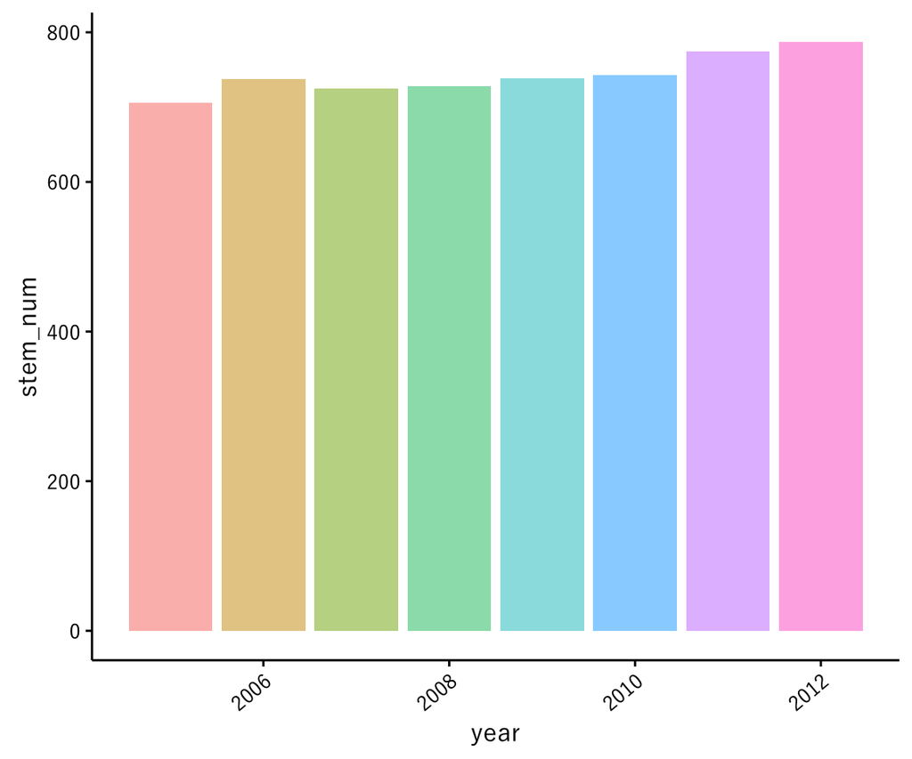

```r
df_uryu_tidy %>% dplyr::select(-note) %>%
  dplyr::filter(!is.na(gbh)) %>%
  group_by(year) %>%
  summarise(stem_num = n()) %>%
  ggplot(aes(year, stem_num, fill = factor(year))) +
  geom_bar(stat = "identity", alpha = 0.5) +
  theme(axis.text.x = element_text(angle = 40, hjust = 1)) +
  guides(fill = FALSE)
```

```r
df_uryu_tidy %>% dplyr::filter(!is.na(gbh)) %>%
  group_by(year, spc_japan) %>%
  summarise(stem_num = n()) %>% {
    tgt_sp <<- dplyr::filter(., stem_num > 50) %$% spc_japan %>% unique()
    p <<- ggplot(., aes(year, stem_num, color = spc_japan)) +
      geom_point(aes(shape = ifelse(stem_num > 50, 16, 21))) +
      geom_line(aes(linetype = ifelse(stem_num > 50, 1, 3))) +
      scale_shape_identity() +
      scale_linetype_identity()
  }
```

```r
tgt_sp
```

```
## [1] "イタヤカエデ" "トドマツ"     "ナナカマド"   "ハリギリ"
## [5] "ミズナラ"
```

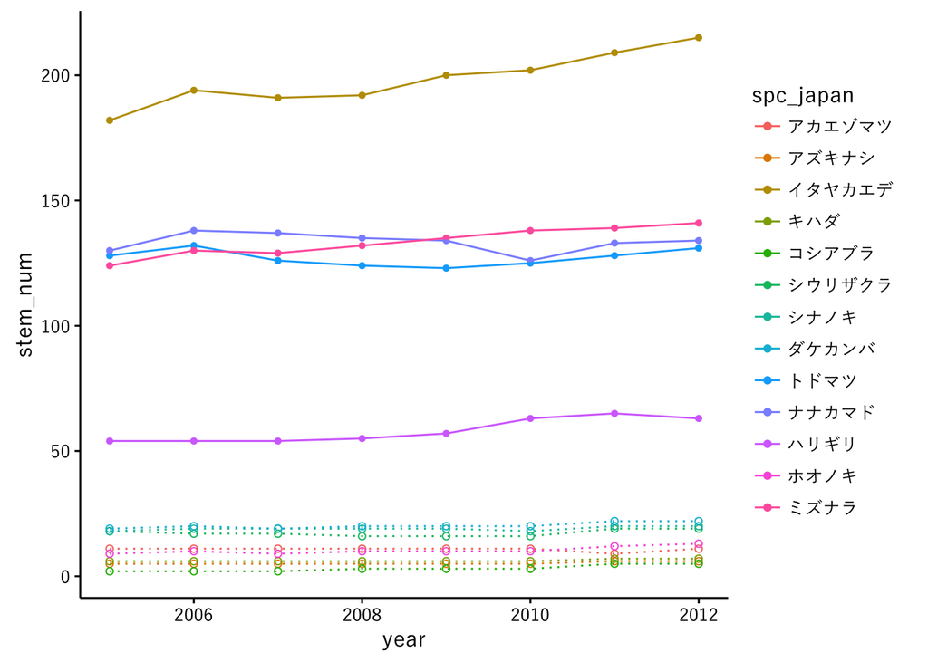

```r
p
```

```r
# modeling
df_uryu_tidy %>% dplyr::filter(spc_japan %in% tgt_sp,
                               year == 2012,
                               !is.na(rgr), rgr > 0) %>%
  glm(formula = rgr ~ gbh,
      family = "Gamma"(link = "log"),
      data = .)
```

```
##
## Call:  glm(formula = rgr ~ gbh, family = Gamma(link = "log"), data = .)
##
## Coefficients:
## (Intercept)          gbh
##   -3.469033    -0.008118
##
## Degrees of Freedom: 561 Total (i.e. Null);  560 Residual
## Null Deviance:       343
## Residual Deviance: 258.7     AIC: -3518
```

種ごとの傾向を確認したい時には`dplyr::do()`を使うと良いです。

```r
uryu_glm_broom <- df_uryu_tidy %>% dplyr::filter(spc_japan %in% tgt_sp,
                                                 year == 2012,
                                                 !is.na(rgr), rgr > 0) %>%
  group_by(spc_japan) %>%
  do(glm(formula = rgr ~ gbh,
         family = "Gamma"(link = "log"),
         data = .) %>%
       tidy())


uryu_glm_broom

# uryu_glm %>% do(
#   data.frame(spc_japan   = .$spc_japan,
#              intercept = coef(.$glm.res)[1],
#              slope     = coef(.$glm.res)[2],
#              aic       = AIC(.$glm.res)))
```

[output not shown]

```r
df_uryu_tidy %>% dplyr::filter(spc_japan %in% tgt_sp,
                               year == 2012,
                               !is.na(rgr), rgr > 0, rgr < 0.10) %>%
  ggplot(aes(gbh, rgr)) +
  geom_point(aes(colour = spc_japan), size = 2, shape = 21, stroke = 1) +
  geom_smooth(method = "glm",
              method.args = list(family = "Gamma"(link = "log")),
              se = FALSE) +
  facet_wrap(~ spc_japan, scales = "free_x", ncol = 5) +
  guides(colour = FALSE)
```

[output not shown]

さらにこうした種の効果を考慮するモデルとして、一般化線形モデルよりも一般化混合線形モデルが適しています、がここは割愛します。

### 元に戻す

```r
df_uryu_tidy %>% dplyr::select(-rgr) %>% {
  tmp_df_gbh <<- dplyr::select(., -note) %>%
    unite(col = indv_id, obs_first, id, sep = "_") %>%
    spread(key = year, value = gbh) %>%
    dplyr::rename(gbh05 = `2005`,
                  gbh06 = `2006`,
                  gbh07 = `2007`,
                  gbh08 = `2008`,
                  gbh09 = `2009`,
                  gbh10 = `2010`,
                  gbh11 = `2011`,
                  gbh12 = `2012`)
  tmp_df_note <<- dplyr::select(., -gbh) %>%
    unite(col = indv_id, obs_first, id, sep = "_") %>%
    spread(key = year, value = note) %>%
    dplyr::rename(note05 = `2005`,
                  note06 = `2006`,
                  note07 = `2007`,
                  note08 = `2008`,
                  note09 = `2009`,
                  note10 = `2010`,
                  note11 = `2011`,
                  note12 = `2012`)
}
df_uryu_untidy <- tmp_df_gbh %>% inner_join(tmp_df_note)
dim(df_uryu_untidy)
```

[output not shown]

**`{dplyr}`**と比べると関数が少ないので覚えやすいと思うので、皆さんもtidyってください。

### おまけ

明日のR Advent Calendar 2015の担当者は@u_ribo です！！！

（連投になりますが、ご了承ください。３日からは豪華なメンバーによる記事が続きます）。

## 参考

- 市川 (2014). データサイエンティスト養成読本 R活用編.
- RStudio チートシート
- vimeo
- hadley